# Analyzing Individual BGG Users

Phil Henrickson

2022-01-01

# **Biggy_serg’s** BoardGameGeek Collection

This notebook contains a set of analyses for the selected user’s boardgamegeek collection. The bulk of the analysis is focused on building a user-specific predictive model to predict the games that Biggy_serg is likely to own. This enables to ask questions like, based on the games the user currently owns, what games are a good fit for their collection? What upcoming games are they likely to purchase?

This analysis is based on data from BoardGameGeek that was last updated on **2021-12-20.**

# 1 Collection Overview

We can look at a basic description of the number of games that the user owns, has rated, has previously owned, etc.

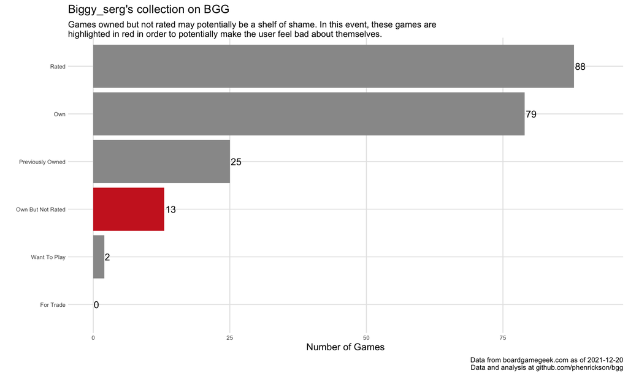

What years has the user owned/rated games from? While we can’t see when a user added or removed a game from their collection, we can look at their collection by the years in which their games were published.

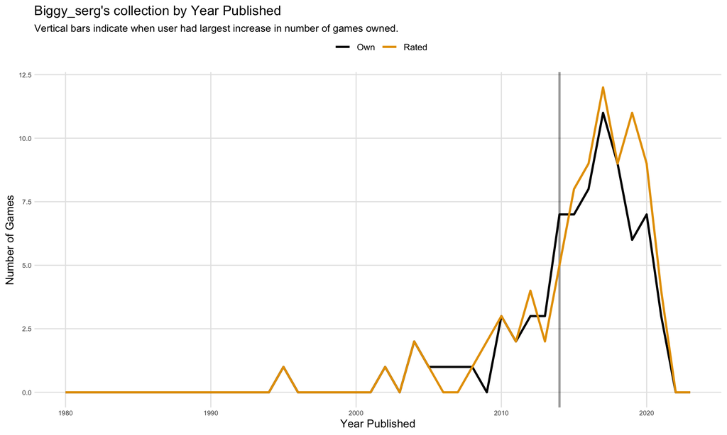

## 1.1 What types of games does Biggy_serg own?

We can look at the most frequent types of categories, mechanics, designers, and artists that appear in a user’s collection.

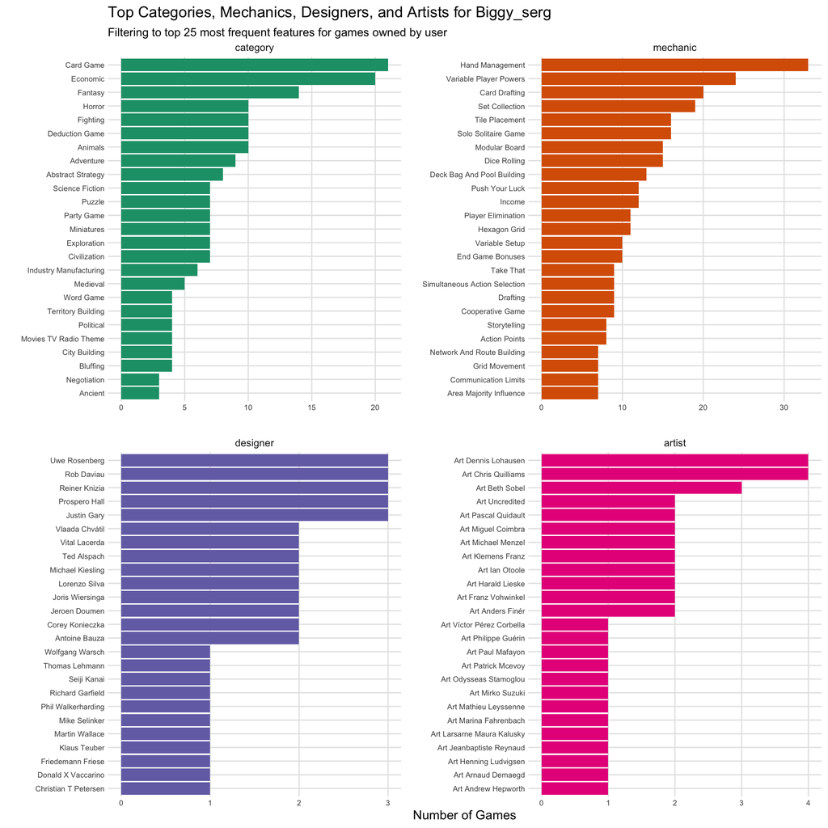

# 2 Modeling **Biggy_serg’s** Collection

| username | dataset | period | games_owned | games_rated | games_played |
| --- | --- | --- | --- | --- | --- |
| Biggy_serg | training | published before 2020 | 69 | 74 | 92 |
| Biggy_serg | test | published 2020 or later | 10 | 13 | 18 |

There are two main (binary) outcomes we will be modeling for the user.

The first, **own** refers to whether the user currently lists a game as owned in their collection. The second, **played** refers to whether the user currently owns, has rated, or previously owned a game. This means the latter will generally have a larger list of games, but may still be a useful category to examine for people who play lots of games without necessarily owning them.

We will train predictive models to learn the probability that the user will own or play individual games based on their features.

## 2.1 Coefficients for Biggy_serg

We can examine coefficients from the trained modes, which are penalized logistic regressions fit to our two main outcomes. Positive values indicate that a feature increases a user’s probabilility of owning/rating a game, while negative values indicate a feature decreases the probability.

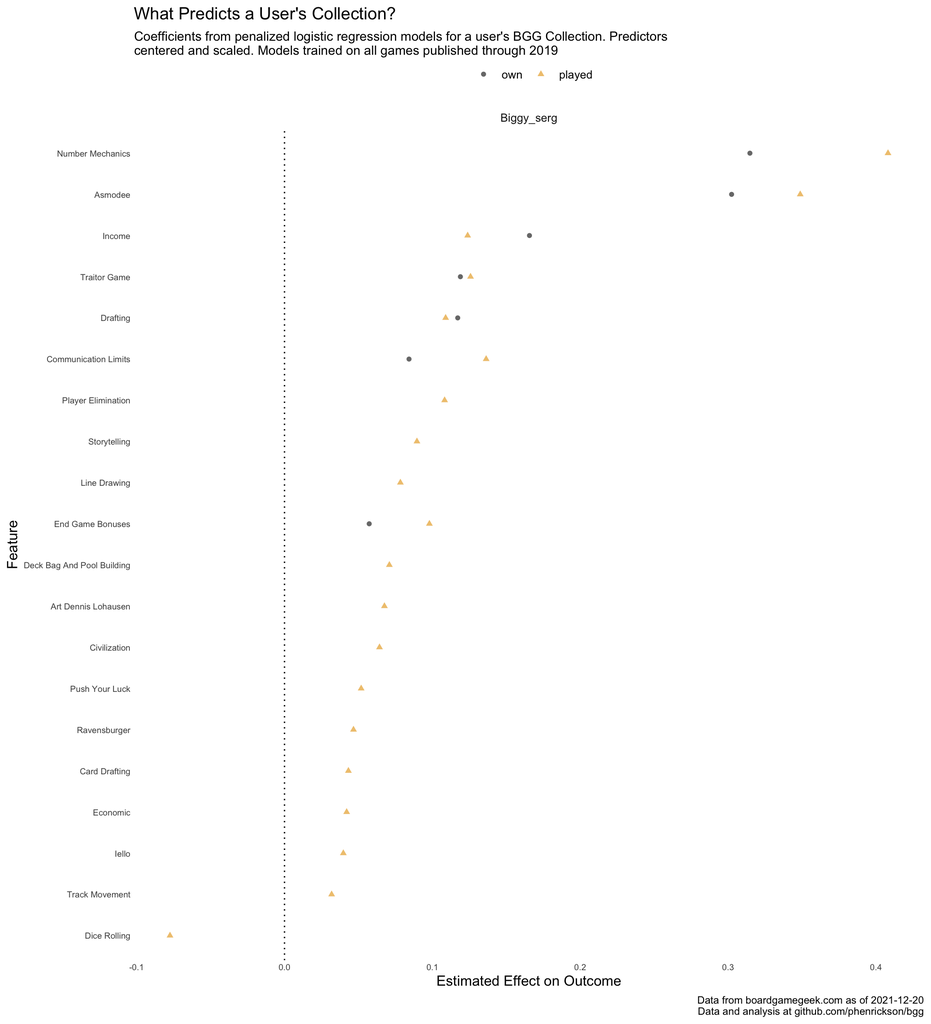

## 2.2 Visualizing Predictors for Biggy_serg’s Collection

Why did the model identify these features? We can make density plots of the important features for predicting whether the user owned a game. Blue indicates the density for games owned by the user, while grey indicates the density for games not owned by the user.

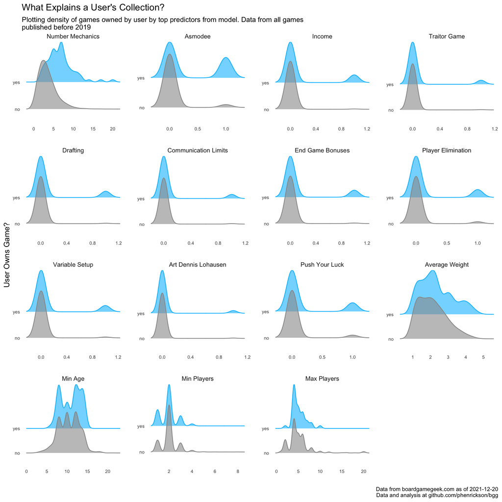

Binary predictors can be difficult to see with this visualization, so we can also directly examine the percentage of games in a user’s collection with a predictor vs the percentage of all games with that predictor.

| username | Feature | % of Games with Feature In_Collection | % of Games with Feature All_Games | Ratio |
| --- | --- | --- | --- | --- |
| Biggy_serg | Income | 15.9% | 0.6% | 26.7 |
| Biggy_serg | Traitor Game | 8.7% | 0.6% | 14.2 |
| Biggy_serg | Drafting | 13.0% | 1.0% | 13.7 |
| Biggy_serg | End Game Bonuses | 14.5% | 1.2% | 12.3 |
| Biggy_serg | Communication Limits | 8.7% | 0.9% | 9.3 |
| Biggy_serg | Variable Setup | 13.0% | 1.8% | 7.2 |
| Biggy_serg | Asmodee | 36.2% | 5.1% | 7.1 |
| Biggy_serg | Player Elimination | 15.9% | 3.9% | 4.0 |
| Biggy_serg | Horror | 13.0% | 3.9% | 3.4 |
| Biggy_serg | Push Your Luck | 17.4% | 5.2% | 3.3 |
| Biggy_serg | Word Game | 5.8% | 1.7% | 3.3 |
| Biggy_serg | Prehistoric | 2.9% | 1.0% | 2.8 |
| Biggy_serg | Puzzle | 8.7% | 3.3% | 2.6 |
| Biggy_serg | Deduction Game | 14.5% | 6.4% | 2.3 |
| Biggy_serg | Trains | 2.9% | 2.2% | 1.3 |
| Biggy_serg | Negotiation | 4.3% | 3.7% | 1.2 |
| Biggy_serg | Party Game | 10.1% | 8.5% | 1.2 |
| Biggy_serg | Medieval | 7.2% | 6.3% | 1.1 |
| Biggy_serg | City Building | 4.3% | 4.3% | 1.0 |
| Biggy_serg | Racing | 2.9% | 2.8% | 1.0 |
| Biggy_serg | Realtime | 2.9% | 4.2% | 0.7 |
| Biggy_serg | Action Dexterity | 2.9% | 4.8% | 0.6 |
| Biggy_serg | Trivia | 0.0% | 1.8% | 0.0 |
| Biggy_serg | Mafia | 0.0% | 0.7% | 0.0 |
| Biggy_serg | Sports | 0.0% | 2.0% | 0.0 |

# 3 Assess Model’s Performance on Training Set

Before predicting games in upcoming years, we can examine how well the model did and what games it liked in the training set. In this case, we used resampling techniques (cross validation) to ensure that the model had not seen a game before making its predictions.

## 3.1 Separation Plot

An easy way to examine the performance of classification model is to view a separation plot. We plot the predicted probabilities from the model for every game (from resampling) from lowest to highest. We then overlay a blue line for any game that the user does own. A good classifier is one that is able to *separate* the blue (games owned by the user) from the white (games not owned by the user), with most of the blue occurring at the highest probabilities (right side of the chart).

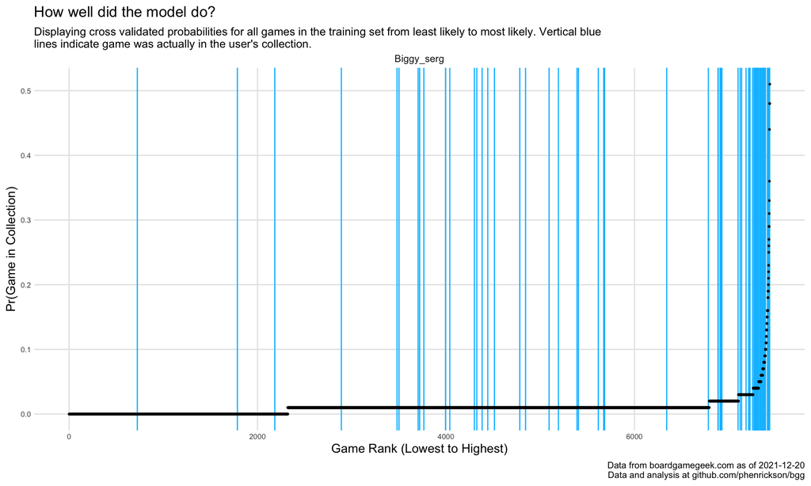

## 3.2 Top Games for **Biggy_serg** from Training Set

We can display this information in table form, displaying the 100 games with the highest probability of ownership, adding a blue line when the user does own the game.

| username | yearpublished | game_id | name | pred_played | pred_own | actual_played | actual_own |
| --- | --- | --- | --- | --- | --- | --- | --- |
| Biggy_serg | 2018 | 244711 | Newton | 0.75 | 0.51 | 0 | 0 |
| Biggy_serg | 2014 | 163412 | Patchwork | 0.28 | 0.48 | 1 | 1 |
| Biggy_serg | 2019 | 270971 | Era: Medieval Age | 0.78 | 0.48 | 0 | 0 |
| Biggy_serg | 2016 | 167791 | Terraforming Mars | 0.44 | 0.44 | 1 | 1 |
| Biggy_serg | 2018 | 205896 | Rising Sun | 0.40 | 0.36 | 0 | 0 |
| Biggy_serg | 2014 | 146886 | La Granja | 0.28 | 0.33 | 0 | 0 |
| Biggy_serg | 2017 | 174430 | Gloomhaven | 0.83 | 0.31 | 1 | 1 |
| Biggy_serg | 2019 | 276025 | Maracaibo | 0.42 | 0.29 | 0 | 0 |
| Biggy_serg | 2016 | 72321 | The Networks | 0.14 | 0.29 | 0 | 0 |
| Biggy_serg | 2014 | 156129 | Deception: Murder in Hong Kong | 0.55 | 0.27 | 0 | 0 |
| Biggy_serg | 2015 | 181687 | The Pursuit of Happiness | 0.20 | 0.26 | 0 | 0 |
| Biggy_serg | 2018 | 247236 | Duelosaur Island | 0.19 | 0.25 | 0 | 0 |
| Biggy_serg | 2017 | 220308 | Gaia Project | 0.49 | 0.23 | 0 | 0 |
| Biggy_serg | 2012 | 105551 | Archipelago | 0.36 | 0.22 | 1 | 0 |
| Biggy_serg | 2005 | 17133 | Railways of the World | 0.19 | 0.21 | 0 | 0 |
| Biggy_serg | 1995 | 13 | Catan | 0.26 | 0.20 | 1 | 1 |
| Biggy_serg | 2015 | 170216 | Blood Rage | 0.21 | 0.19 | 0 | 0 |
| Biggy_serg | 1995 | 46 | Medici | 0.30 | 0.19 | 0 | 0 |
| Biggy_serg | 2019 | 286096 | Tapestry | 0.19 | 0.19 | 0 | 0 |
| Biggy_serg | 2017 | 193728 | Pendragon: The Fall of Roman Britain | 0.13 | 0.18 | 0 | 0 |
| Biggy_serg | 2016 | 205398 | Citadels | 0.15 | 0.18 | 0 | 0 |
| Biggy_serg | 2015 | 204184 | Risk: Europe | 0.07 | 0.16 | 0 | 0 |
| Biggy_serg | 2017 | 218603 | Photosynthesis | 0.32 | 0.16 | 1 | 1 |
| Biggy_serg | 2017 | 221194 | Dinosaur Island | 0.09 | 0.16 | 1 | 1 |
| Biggy_serg | 1933 | 1406 | Monopoly | 0.10 | 0.16 | 0 | 0 |
| Biggy_serg | 2005 | 15062 | Shadows over Camelot | 0.24 | 0.16 | 0 | 0 |
| Biggy_serg | 2004 | 9220 | Saboteur | 0.35 | 0.16 | 0 | 0 |
| Biggy_serg | 2018 | 224517 | Brass: Birmingham | 0.15 | 0.15 | 0 | 0 |
| Biggy_serg | 2019 | 251247 | Barrage | 0.14 | 0.15 | 0 | 0 |
| Biggy_serg | 2012 | 123096 | Space Cadets | 0.18 | 0.15 | 0 | 0 |

[output cut: 70 more lines]

We can also more formally assess how well the model did in resampling by looking at the area under the receiver operating characteristic. A perfect model would receive a score of 1, while a model that cannot predict the outcome will default to a score of 0.5. The extent to which something is a *good* score depends on the setting, but generally anything in the .8 to .9 range is very good while the .7 to .8 range is perfectly acceptable.

| username | outcome_type | .metric | .estimator | .estimate |
| --- | --- | --- | --- | --- |
| Biggy_serg | own | roc_auc | binary | 0.872 |
| Biggy_serg | played | roc_auc | binary | 0.855 |

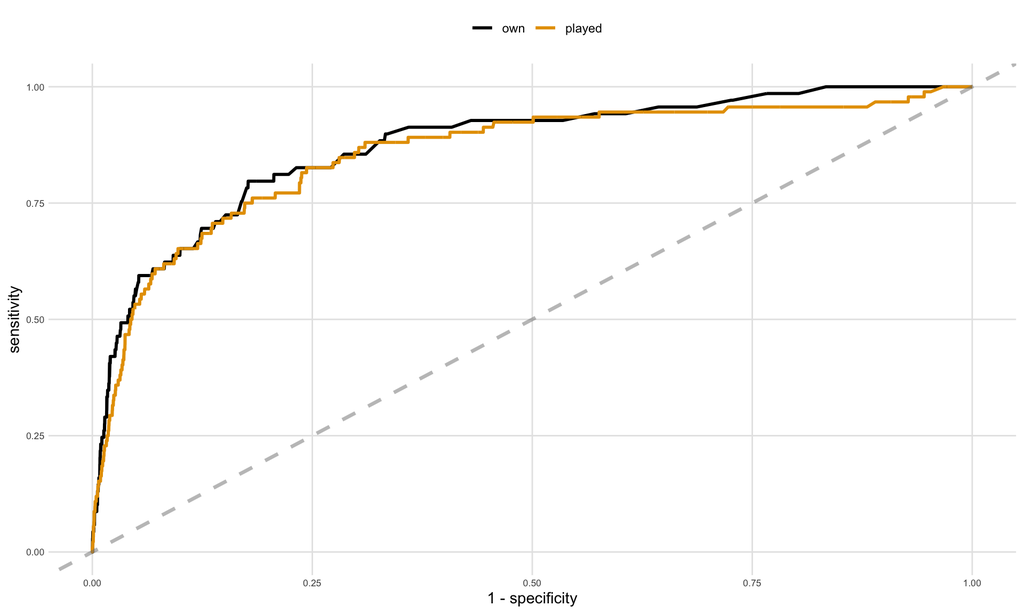

Another way to think about the model performance is to view its lift, or its ability to detect the positive outcomes over that of a null model. High lift indicates the model can much more quickly find all of the positive outcomes (in this case, games owned or played by the user), while a model with no lift is no better than random guessing.

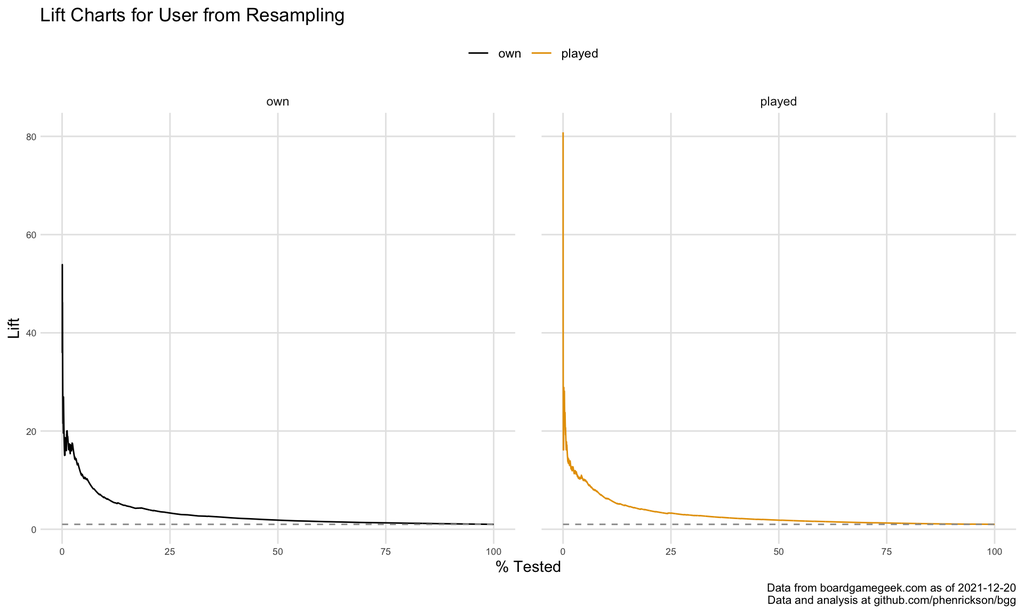

## 3.3 Most and Least Likely Games

What games does the model think Biggy_serg is **most likely to own** that are **not** in their collection?

| username | yearpublished | game_id | name | pred_own | actual_own |
| --- | --- | --- | --- | --- | --- |
| Biggy_serg | 2018 | 244711 | Newton | 0.51 | 0 |
| Biggy_serg | 2019 | 270971 | Era: Medieval Age | 0.48 | 0 |
| Biggy_serg | 2018 | 205896 | Rising Sun | 0.36 | 0 |
| Biggy_serg | 2014 | 146886 | La Granja | 0.33 | 0 |
| Biggy_serg | 2019 | 276025 | Maracaibo | 0.29 | 0 |

What games does the model think Biggy_serg is **least likely to own** that **are** in their collection?

| username | yearpublished | game_id | name | pred_own | actual_own |
| --- | --- | --- | --- | --- | --- |
| Biggy_serg | 1929 | 2407 | Sorry! | 0.00 | 1 |
| Biggy_serg | 2019 | 266083 | L.L.A.M.A. | 0.00 | 1 |
| Biggy_serg | 2015 | 136991 | Loony Quest | 0.00 | 1 |
| Biggy_serg | 2014 | 160477 | Onitama | 0.01 | 1 |
| Biggy_serg | 2005 | 12692 | Gloom | 0.01 | 1 |

## 3.4 Top Games by Year

Top 25 games most likely to be owned by the user in each year, highlighting in blue the games that the user has owned/played.

| rank | 2011 | 2012 | 2013 | 2014 | 2015 | 2016 | 2017 | 2018 | 2019 |
| --- | --- | --- | --- | --- | --- | --- | --- | --- | --- |
| 1 | Space Empires: 4X | Archipelago | Prosperity | Patchwork | The Pursuit of Happiness | Terraforming Mars | Gloomhaven | Newton | Era: Medieval Age |
| 2 | Takenoko | Space Cadets | Spyrium | La Granja | Blood Rage | The Networks | Gaia Project | Rising Sun | Maracaibo |
| 3 | Mage Knight Board Game | Seasons | Room 25 | Deception: Murder in Hong Kong | Risk: Europe | Citadels | Pendragon: The Fall of Roman Britain | Duelosaur Island | Tapestry |
| 4 | Octopus's Garden | The Manhattan Project | Concept | Spyfall | The Bloody Inn | New Angeles | Photosynthesis | Brass: Birmingham | Barrage |
| 5 | Eclipse | Pax Porfiriana | Lewis & Clark: The Expedition | Witness | Mysterium | Codenames: Deep Undercover | Dinosaur Island | Everdell | Yukon Airways |
| 6 | Panic Station | Terra Mystica | Sushi Go! | Fields of Arle | The Voyages of Marco Polo | Black Orchestra | This War of Mine: The Board Game | Underwater Cities | The Magnificent |
| 7 | Flash Point: Fire Rescue | Zombicide | Dungeon Twister: The Card Game | Sheep & Thief | Food Chain Magnate | Mansions of Madness: Second Edition | Harvest Dice | Nemesis | The Isle of Cats |
| 8 | A Few Acres of Snow | Kill the Overlord | Rivet Wars: Eastern Front | Akrotiri | Codenames | Dead of Winter: The Long Night | Codenames: Duet | Betrayal Legacy | Clank!: Legacy – Acquisitions Incorporated |
| 9 | Rory's Story Cubes: Voyages | Libertalia | BANG! The Dice Game | Deus | 504 | A Feast for Odin | Breaking Bad: The Board Game | Franchise | Obscurio |
| 10 | Dark Moon | Keyflower | Zombicide Season 2: Prison Outbreak | Colt Express | Through the Ages: A New Story of Civilization | Islebound | Twilight Imperium: Fourth Edition | Dice Hospital | Florenza Dice Game |
| 11 | Evo (Second Edition) | The Resistance: Avalon | Bruxelles 1893 | Saint Petersburg (Second Edition) | Salem 1692 | When I Dream | Unfair | Lords of Hellas | Last Bastion |
| 12 | Ascension: Return of the Fallen | Mice and Mystics | The Ravens of Thri Sahashri | Sheriff of Nottingham | One Night Ultimate Vampire | Captain Sonar | Pandemic Legacy: Season 2 | Who Goes There? | Amul |
| 13 | Streams | Serenissima (Second Edition) | Pizza Party | Irish Gauge | Tiny Epic Galaxies | Junk Art | Century: Spice Road | Pax Emancipation | Minecraft: Builders & Biomes |
| 14 | The Secret of Monte Cristo | Il Vecchio | Pathfinder Adventure Card Game: Rise of the Runelords – Base Set | Imperial Settlers | Exploding Kittens: NSFW Deck | Secret Hitler | Pulsar 2849 | Gen7: A Crossroads Game | Black Angel |
| 15 | Ascension: Storm of Souls | Among the Stars | City of Remnants | Five Tribes | FUSE | Hit Z Road | Fallout | Azul: Stained Glass of Sintra | Tainted Grail: The Fall of Avalon |
| 16 | Tragedy Looper | One Night Werewolf | Berserk: War of the Realms | Arcadia Quest | T.I.M.E Stories | Pandemic: Reign of Cthulhu | Azul | Gingerbread House | The King's Dilemma |
| 17 | Dixit: Odyssey | Dixit: Journey | Castle Dice | Abyss | Bastion | Burke's Gambit | The Thing: Infection at Outpost 31 | Hail Hydra | It's a Wonderful World |
| 18 | Letters from Whitechapel | Rumble in the Dungeon | Corto | Black Fleet | The Builders: Antiquity | The Oregon Trail Card Game | Exploding Kittens: Party Pack | Decrypto | Crystal Palace |
| 19 | Mundus Novus | Dixit Jinx | Ascension: Rise of Vigil | Pictopia: Disney Edition | Best Treehouse Ever | The Others | The Godfather: Corleone's Empire | Shadows: Amsterdam | Call to Adventure |
| 20 | A Game of Thrones: The Board Game (Second Edition) | Diavolo | The Builders: Middle Ages | Hyperborea | Zombicide Season 3: Rue Morgue | 13 Days: The Cuban Missile Crisis | Paper Tales | One Week Ultimate Werewolf | Aquatica |
| 21 | Skull | Descent: Journeys in the Dark (Second Edition) | Patchistory | Don't Mess with Cthulhu | Watson & Holmes | Inis | Bunny Kingdom | Pandemic: Fall of Rome | GROWL |
| 22 | Rumble in the House | Kemet | Koryŏ | Power Grid Deluxe: Europe/North America | Aye, Dark Overlord! The Green Box | Roll Player | Whitehall Mystery | A Song of Ice & Fire: Tabletop Miniatures Game – Stark vs Lannister Starter Set | Wingspan |
| 23 | Québec | War of the Ring: Second Edition | Cappuccino | HINT | One Night Ultimate Werewolf: Daybreak | Harry Potter: Hogwarts Battle | Sagrada | Kero | Sierra West |
| 24 | Seven Dragons | Wiz-War (Eighth Edition) | Mascarade | One Night Ultimate Werewolf | Homeland: The Game | Capital Lux | A Tale of Pirates | Stuffed Fables | Old West Empresario |
| 25 | Tales & Games: The Hare & the Tortoise | Divinare | Ultimate Werewolf: Inquisition | Praetor | Nevermore | Beyond Baker Street | Secrets | Fireball Island: The Curse of Vul-Kar | MegaCity: Oceania |

## 3.5 Interactive Predictions from Resampling

Interactive table for predictions from resampling.

|  | username | yearpublished | rank | game_id | name | pred_played | pred_own | actual_played | actual_own |
| --- | --- | --- | --- | --- | --- | --- | --- | --- | --- |
| 1 | Biggy_serg | 1900 | 283 | 45 | Perudo | 0.06 | 0.03 | 0 | 0 |
| 2 | Biggy_serg | 1900 | 527 | 15878 | Rummy | 0.03 | 0.02 | 0 | 0 |
| 3 | Biggy_serg | 1900 | 693 | 188 | Go | 0.01 | 0.01 | 0 | 0 |
| 4 | Biggy_serg | 1900 | 781 | 171 | Chess | 0.01 | 0.01 | 0 | 0 |
| 5 | Biggy_serg | 1900 | 789 | 2065 | Shogi | 0.01 | 0.01 | 0 | 0 |
| 6 | Biggy_serg | 1900 | 973 | 1602 | The Royal Game of Ur | 0.01 | 0.01 | 0 | 0 |
| 7 | Biggy_serg | 1900 | 974 | 2083 | Checkers | 0.01 | 0.01 | 0 | 0 |
| 8 | Biggy_serg | 1900 | 979 | 2389 | Othello | 0 | 0.01 | 0 | 0 |
| 9 | Biggy_serg | 1900 | 980 | 2397 | Backgammon | 0.01 | 0.01 | 0 | 0 |
| 10 | Biggy_serg | 1900 | 1196 | 2932 | Hnefatafl | 0.01 | 0.01 | 0 | 0 |

[output cut: 7426 more lines]

# 4 Validating the Model on 2020

How well did a model trained on a user’s collection through 2019 perform in predicting games for the user from 2020?

| username | outcome_type | yearpublished | .metric | .estimator | .estimate |
| --- | --- | --- | --- | --- | --- |
| Biggy_serg | own | 2020 | roc_auc | binary | 0.793 |
| Biggy_serg | played | 2020 | roc_auc | binary | 0.819 |

Table of top 25 games from 2020, highlighting games that the user owns.

| username | yearpublished | game_id | name | pred_own | pred_played | actual_own | actual_played |
| --- | --- | --- | --- | --- | --- | --- | --- |
| Biggy_serg | 2020 | 184267 | On Mars | 0.54 | 0.67 | 0 | 0 |
| Biggy_serg | 2020 | 256317 | Guild Master | 0.30 | 0.44 | 0 | 0 |
| Biggy_serg | 2020 | 291457 | Gloomhaven: Jaws of the Lion | 0.25 | 0.55 | 1 | 1 |
| Biggy_serg | 2020 | 246900 | Eclipse: Second Dawn for the Galaxy | 0.16 | 0.26 | 0 | 0 |
| Biggy_serg | 2020 | 297030 | Tekhenu: Obelisk of the Sun | 0.16 | 0.10 | 0 | 0 |
| Biggy_serg | 2020 | 300322 | Hallertau | 0.16 | 0.23 | 0 | 0 |
| Biggy_serg | 2020 | 308765 | Praga Caput Regni | 0.13 | 0.19 | 0 | 0 |
| Biggy_serg | 2020 | 294788 | Conqueror: Final Conquest | 0.11 | 0.12 | 0 | 0 |
| Biggy_serg | 2020 | 320819 | Dinner in Paris | 0.11 | 0.14 | 0 | 0 |
| Biggy_serg | 2020 | 316377 | 7 Wonders (Second Edition) | 0.09 | 0.20 | 0 | 0 |
| Biggy_serg | 2020 | 303057 | Pan Am | 0.08 | 0.07 | 1 | 1 |
| Biggy_serg | 2020 | 294047 | Superclub | 0.07 | 0.06 | 0 | 0 |
| Biggy_serg | 2020 | 298352 | The Shining | 0.07 | 0.09 | 0 | 0 |
| Biggy_serg | 2020 | 310442 | Feierabend | 0.07 | 0.07 | 0 | 0 |
| Biggy_serg | 2020 | 301767 | Mysterium Park | 0.06 | 0.20 | 0 | 0 |
| Biggy_serg | 2020 | 302465 | Obsidia | 0.06 | 0.07 | 0 | 0 |
| Biggy_serg | 2020 | 217990 | Stellar Horizons | 0.05 | 0.05 | 0 | 0 |
| Biggy_serg | 2020 | 295577 | Dungeon Mayhem: Monster Madness | 0.05 | 0.06 | 0 | 0 |
| Biggy_serg | 2020 | 304434 | Victim: The Cursed Forest | 0.05 | 0.09 | 0 | 0 |
| Biggy_serg | 2020 | 316554 | Dune: Imperium | 0.05 | 0.11 | 1 | 1 |
| Biggy_serg | 2020 | 291874 | Dwergar | 0.04 | 0.08 | 0 | 0 |
| Biggy_serg | 2020 | 292333 | Cowboys II: Cowboys & Indians Edition | 0.04 | 0.09 | 0 | 0 |
| Biggy_serg | 2020 | 296892 | Sacred Rites | 0.04 | 0.09 | 0 | 0 |
| Biggy_serg | 2020 | 297204 | Traintopia | 0.04 | 0.05 | 0 | 0 |
| Biggy_serg | 2020 | 299960 | Alma Mater | 0.04 | 0.05 | 0 | 0 |

# 5 Predicting Upcoming Games (2020 and On) for **Biggy_serg**

Examine the top games for the test set.

| username | yearpublished | game_id | name | rank | own | played |
| --- | --- | --- | --- | --- | --- | --- |
| Biggy_serg | 2020 | 184267 | On Mars | 1 | 0.54 | 0.67 |
| Biggy_serg | 2020 | 256317 | Guild Master | 2 | 0.30 | 0.44 |
| Biggy_serg | 2020 | 291457 | Gloomhaven: Jaws of the Lion | 3 | 0.25 | 0.55 |
| Biggy_serg | 2020 | 246900 | Eclipse: Second Dawn for the Galaxy | 4 | 0.16 | 0.26 |
| Biggy_serg | 2020 | 300322 | Hallertau | 5 | 0.16 | 0.23 |
| Biggy_serg | 2020 | 297030 | Tekhenu: Obelisk of the Sun | 6 | 0.16 | 0.10 |
| Biggy_serg | 2020 | 308765 | Praga Caput Regni | 7 | 0.13 | 0.19 |
| Biggy_serg | 2020 | 294788 | Conqueror: Final Conquest | 8 | 0.11 | 0.12 |
| Biggy_serg | 2020 | 320819 | Dinner in Paris | 9 | 0.11 | 0.14 |
| Biggy_serg | 2020 | 316377 | 7 Wonders (Second Edition) | 10 | 0.09 | 0.20 |
| Biggy_serg | 2020 | 303057 | Pan Am | 11 | 0.08 | 0.07 |
| Biggy_serg | 2020 | 294047 | Superclub | 12 | 0.07 | 0.06 |
| Biggy_serg | 2020 | 310442 | Feierabend | 13 | 0.07 | 0.07 |
| Biggy_serg | 2020 | 298352 | The Shining | 14 | 0.07 | 0.09 |
| Biggy_serg | 2020 | 301767 | Mysterium Park | 15 | 0.06 | 0.20 |
| Biggy_serg | 2020 | 302465 | Obsidia | 16 | 0.06 | 0.07 |
| Biggy_serg | 2020 | 316554 | Dune: Imperium | 17 | 0.05 | 0.11 |
| Biggy_serg | 2020 | 217990 | Stellar Horizons | 18 | 0.05 | 0.05 |
| Biggy_serg | 2020 | 295577 | Dungeon Mayhem: Monster Madness | 19 | 0.05 | 0.06 |
| Biggy_serg | 2020 | 304434 | Victim: The Cursed Forest | 20 | 0.05 | 0.09 |
| Biggy_serg | 2020 | 314040 | Pandemic Legacy: Season 0 | 21 | 0.04 | 0.05 |
| Biggy_serg | 2020 | 299960 | Alma Mater | 22 | 0.04 | 0.05 |
| Biggy_serg | 2020 | 307844 | Atheneum: Mystic Library | 23 | 0.04 | 0.06 |
| Biggy_serg | 2020 | 297204 | Traintopia | 24 | 0.04 | 0.05 |
| Biggy_serg | 2020 | 291874 | Dwergar | 25 | 0.04 | 0.08 |
| Biggy_serg | 2021 | 310873 | Carnegie | 1 | 0.27 | 0.40 |
| Biggy_serg | 2021 | 343905 | Boonlake | 2 | 0.21 | 0.48 |
| Biggy_serg | 2021 | 298383 | Golem | 3 | 0.19 | 0.15 |
| Biggy_serg | 2021 | 291847 | Mantis Falls | 4 | 0.17 | 0.26 |
| Biggy_serg | 2021 | 342942 | Ark Nova | 5 | 0.16 | 0.36 |
| Biggy_serg | 2021 | 340466 | Unfathomable | 6 | 0.12 | 0.22 |
| Biggy_serg | 2021 | 291859 | Riftforce | 7 | 0.12 | 0.18 |
| Biggy_serg | 2021 | 320446 | Corduba 27 a.C. | 8 | 0.11 | 0.12 |
| Biggy_serg | 2021 | 295535 | Dark Ages: Heritage of Charlemagne | 9 | 0.10 | 0.11 |
| Biggy_serg | 2021 | 304985 | Dark Ages: Holy Roman Empire | 10 | 0.10 | 0.11 |
| Biggy_serg | 2021 | 298102 | Roll Camera!: The Filmmaking Board Game | 11 | 0.09 | 0.29 |
| Biggy_serg | 2021 | 331635 | Kameloot | 12 | 0.09 | 0.12 |
| Biggy_serg | 2021 | 309319 | Apogee | 13 | 0.08 | 0.09 |
| Biggy_serg | 2021 | 328569 | Mint Bid | 14 | 0.08 | 0.06 |
| Biggy_serg | 2021 | 290618 | Wishland | 15 | 0.08 | 0.07 |
| Biggy_serg | 2021 | 238799 | Messina 1347 | 16 | 0.07 | 0.08 |
| Biggy_serg | 2021 | 327971 | Hippocrates | 17 | 0.07 | 0.06 |
| Biggy_serg | 2021 | 285967 | Ankh: Gods of Egypt | 18 | 0.07 | 0.17 |
| Biggy_serg | 2021 | 299684 | Khôra: Rise of an Empire | 19 | 0.06 | 0.05 |
| Biggy_serg | 2021 | 328871 | Terraforming Mars: Ares Expedition | 20 | 0.06 | 0.04 |
| Biggy_serg | 2021 | 292375 | The Great Wall | 21 | 0.06 | 0.05 |
| Biggy_serg | 2021 | 310100 | Nemesis: Lockdown | 22 | 0.05 | 0.10 |
| Biggy_serg | 2021 | 317457 | Dinosaur World | 23 | 0.05 | 0.03 |
| Biggy_serg | 2021 | 341256 | Murano: Light Masters | 24 | 0.05 | 0.03 |
| Biggy_serg | 2021 | 316287 | Quest | 25 | 0.05 | 0.08 |
| Biggy_serg | 2022 | 317511 | Tindaya | 1 | 0.19 | 0.47 |
| Biggy_serg | 2022 | 331106 | The Witcher: Old World | 2 | 0.10 | 0.25 |
| Biggy_serg | 2022 | 295770 | Frosthaven | 3 | 0.07 | 0.23 |
| Biggy_serg | 2022 | 330950 | Age of Galaxy | 4 | 0.07 | 0.10 |
| Biggy_serg | 2022 | 283137 | Human Punishment: The Beginning | 5 | 0.07 | 0.12 |
| Biggy_serg | 2022 | 284189 | Foundations of Rome | 6 | 0.05 | 0.04 |
| Biggy_serg | 2022 | 295895 | Distilled | 7 | 0.05 | 0.05 |
| Biggy_serg | 2022 | 334065 | Verdant | 8 | 0.04 | 0.04 |
| Biggy_serg | 2022 | 322524 | Bardsung | 9 | 0.03 | 0.08 |
| Biggy_serg | 2022 | 299106 | Fractal: Beyond the Void | 10 | 0.02 | 0.03 |
| Biggy_serg | 2022 | 340325 | Vagrantsong | 11 | 0.02 | 0.03 |
| Biggy_serg | 2022 | 324090 | Scarface 1920 | 12 | 0.02 | 0.03 |
| Biggy_serg | 2022 | 326945 | Castles of Mad King Ludwig: Collector's Edition | 13 | 0.02 | 0.03 |
| Biggy_serg | 2022 | 335427 | Wild: Serengeti | 14 | 0.02 | 0.03 |
| Biggy_serg | 2022 | 338067 | 6: Siege – The Board Game | 15 | 0.02 | 0.02 |
| Biggy_serg | 2022 | 256680 | Return to Dark Tower | 16 | 0.02 | 0.03 |
| Biggy_serg | 2022 | 305096 | Endless Winter: Paleoamericans | 17 | 0.02 | 0.04 |
| Biggy_serg | 2022 | 273814 | Deliverance | 18 | 0.02 | 0.05 |
| Biggy_serg | 2022 | 317321 | Darkest Dungeon: The Board Game | 19 | 0.02 | 0.03 |
| Biggy_serg | 2022 | 319807 | Shogun no Katana | 20 | 0.02 | 0.04 |
| Biggy_serg | 2022 | 280726 | Legacies | 21 | 0.02 | 0.05 |
| Biggy_serg | 2022 | 304051 | Creature Comforts | 22 | 0.02 | 0.10 |
| Biggy_serg | 2022 | 260923 | Titan | 23 | 0.01 | 0.01 |
| Biggy_serg | 2022 | 274277 | Jurassic World Miniature Game | 24 | 0.01 | 0.01 |
| Biggy_serg | 2022 | 293941 | Mage Noir | 25 | 0.01 | 0.01 |

## 5.1 Interactive Table for Upcoming Games 2020 and On

|  | username | yearpublished | game_id | name | rank | own | played |
| --- | --- | --- | --- | --- | --- | --- | --- |
| 1 | Biggy_serg | 2020 | 184267 | On Mars | 1 | 0.54 | 0.67 |
| 2 | Biggy_serg | 2020 | 256317 | Guild Master | 2 | 0.3 | 0.44 |
| 3 | Biggy_serg | 2021 | 310873 | Carnegie | 3 | 0.27 | 0.4 |
| 4 | Biggy_serg | 2020 | 291457 | Gloomhaven: Jaws of the Lion | 4 | 0.25 | 0.55 |
| 5 | Biggy_serg | 2021 | 343905 | Boonlake | 5 | 0.21 | 0.48 |
| 6 | Biggy_serg | 2021 | 298383 | Golem | 6 | 0.19 | 0.15 |
| 7 | Biggy_serg | 2022 | 317511 | Tindaya | 7 | 0.19 | 0.47 |
| 8 | Biggy_serg | 2021 | 291847 | Mantis Falls | 8 | 0.17 | 0.26 |
| 9 | Biggy_serg | 2020 | 246900 | Eclipse: Second Dawn for the Galaxy | 9 | 0.16 | 0.26 |
| 10 | Biggy_serg | 2021 | 342942 | Ark Nova | 10 | 0.16 | 0.36 |

[output cut: 1627 more lines]